# RNAmaps of HNRNPH binding on cooperatively regulated CE events

Mario Keller

Faculty of Biological Sciences, Goethe University Frankfurt

28 March 2023

```r
library(tidyverse)
library(knitr)
library(ggpubr)
library(ggbeeswarm)
library(GenomicRanges)
```

```r
myTheme <- theme_bw() +
    theme(axis.text = element_text(size = 14, colour="black"),
          axis.title = element_text(size=16, colour="black"),
          axis.ticks=element_line(color="black"),
          axis.ticks.length=unit(.15, "cm"),
          panel.border=element_rect(color="black", fill = NA),
          panel.background = element_blank(),
          plot.background = element_blank(),
          legend.text = element_text(size=12),
          legend.position = "none")
```

```r
projectDir <- "/Users/mariokeller/projects/HNRNPH_project/Tretow_et_al_2023"

iClipDir <- paste0(projectDir, "/4_iCLIP_analysis")
majiqDir <- paste0(projectDir,"/2_MAJIQ_AS_analysis")
```

# 1 Background

To obtain deeper insights into the binding behavior of HNRNPH, RNAmaps are a valuable tool. By opening windows at fixed positions in the CE events (the four involved splice sites), the iCLIP signal of CE events can be combined to produce a single signal that shows the binding prefernece of HNRNPH in the defined windows. The addition of signal from control (non-regulated) CE events can be added to identify regions with enriched HNRNPH binding.

# 2 Data

Regulated and non-regulated minigenes are loaded from RDS-Files created with *Create_CE_minigenes.R*.

Regulated and non-regulated CE events are loaded from RDS-Files created with *MAJIQ_AS_analysis.Rmd*.

Crosslink sites (the raw iCLIP signal) is loaded from a RDS-File created with *Binding_site_definition.R*.

```r
regulatedMiniGenes <- readRDS(paste0(iClipDir,
                                     "/rds_files/regulatedMiniGenes.rds"))
nonRegulatedMiniGenes <- readRDS(paste0(iClipDir,
                                        "/rds_files/nonregulatedMiniGenes.rds"))

regulatedCEs <- readRDS(paste0(majiqDir,"/rds_files/regulatedCEs.rds"))
nonRegulatedCEs <- readRDS(paste0(majiqDir,"/rds_files/nonregulatedCEs.rds"))

crosslinkSites <- readRDS(paste0(iClipDir,"/rds_files/HNRNPH_crosslink_sites.rds"))
```

As a first step, CE events that do not belong to the “Coop-Enh” or “Coop-Rep” category are removed.

```r
keep <- regulatedMiniGenes %>%
    sapply(., function(gr){gr$hillCat[1]}) %in% c("Coop-Enh", "Coop-Rep")
regulatedMiniGenes <- regulatedMiniGenes[keep]
rm(keep)
```

Here is the total number of events per hill category:

- Coop-Enh: 78
- Coop-Rep: 223
- nonReg: 1151

# 3 Length distribution of exons

Before doing the preparation of the RNAmaps, the length distribution of the three exons involved in the CE events was compared between the Coop-Enh and Coop-Rep category.

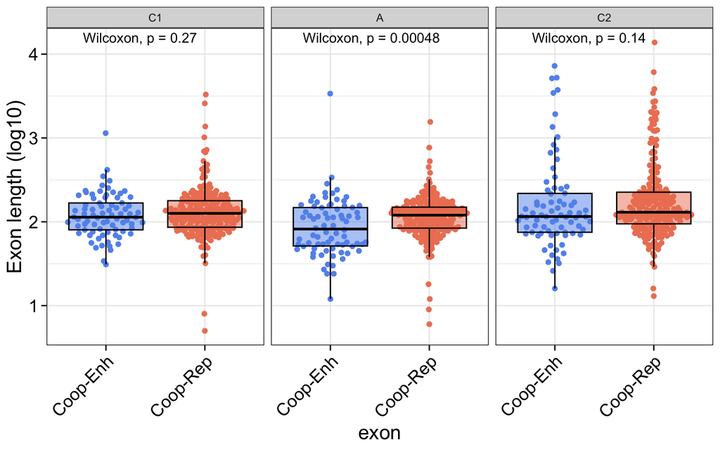

```r
# Extract for each of the 301 CE events the width of the upstream (C1),
#   alternative (A) and downstream exon (C2)
widthColumn <- c(sapply(regulatedMiniGenes,
                        function(gr){width(gr[gr$exon=="C1"])}),
                 sapply(regulatedMiniGenes,
                        function(gr){width(gr[gr$exon=="A"])}),
                 sapply(regulatedMiniGenes,
                        function(gr){width(gr[gr$exon=="C2"])}))

# Define the exon (C1, A or C2)
exonColumn <- factor(c(rep("C1", length(regulatedMiniGenes)),
                       rep("A", length(regulatedMiniGenes)),
                       rep("C2", length(regulatedMiniGenes))),
                     levels=c("C1", "A", "C2"))

# Define the hill category for each exon
hillColumn <- factor(rep(regulatedMiniGenes %>%
                             sapply(., function(gr){gr$hillCat[1]}),
                         3),
                     levels = c("Coop-Enh", "Coop-Rep"))

data.frame(width=widthColumn,
           exon=exonColumn,
           hillCat=hillColumn) %>%
    ggplot(., aes(x=hillCat, y=log10(width), group=hillCat, fill=hillCat, col=hillCat)) +
    geom_quasirandom() +
    geom_boxplot(alpha=.5, outlier.size = -1, col="black") +
    scale_fill_manual(values=c("Coop-Rep" = "salmon2", "Coop-Enh"="cornflowerblue")) +
    scale_color_manual(values=c("Coop-Rep" = "salmon2", "Coop-Enh"="cornflowerblue")) +
    stat_compare_means(method="wilcox.test") +
    labs(x="exon", y="Exon length (log10)") +
    facet_wrap(~exon, ncol=4) +
    myTheme +
    theme(axis.text.x = element_text(angle=45, vjust = 1, hjust = 1))
```

```r
rm(widthColumn, exonColumn, hillColumn)
```

The flanking exons (C1 and C2) show no length differences between the cooperatively enhanced and repressed CE events. In contrast, the cassette/alternative exon (A) itself tends to be longer if the exon is repressed by HNRNPH.

# 4 RNAmaps

## 4.1 PSI distribution in control samples

As the enhanced and repressed CE events have different inclusion levels in the control conditions, their RNAmaps should not be directly compared. It is better to sample sets of non-regulated CE events that roughly mirror the control PSI distribution of the enhanced and repressed CE events.

To demonstrate the differences in the PSI distributions, I extract the knockdown and overexpression PSI estimates of the cooperatively enhanced, repressed and non-regulated CE eventss, average them and plot the distributions.

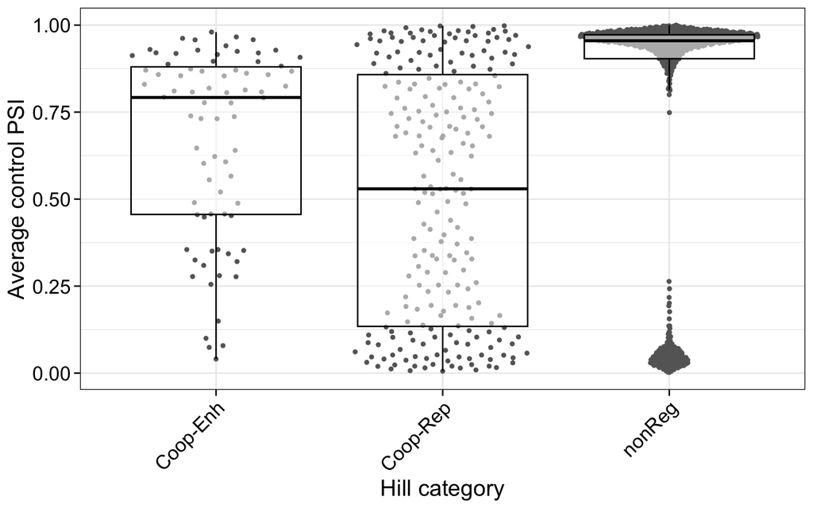

```r
# Filter the regulated CEs for the ones with minigenes and calculate
#   the average control PSI
regulatedCEs <- regulatedCEs %>%
    dplyr::filter(event_id %in% names(regulatedMiniGenes)) %>%
    dplyr::select(event_id, KD_Contr_median_psi, OE_Contr_median_psi) %>%
    mutate(Contr_PSI = rowMeans(dplyr::select(.,ends_with("Contr_median_psi"))))

nonRegulatedCEs <- nonRegulatedCEs %>%
    dplyr::filter(event_id %in% names(nonRegulatedMiniGenes)) %>%
    dplyr::select(event_id, KD_Contr_median_psi, OE_Contr_median_psi) %>%
    mutate(Contr_PSI = rowMeans(dplyr::select(.,ends_with("Contr_median_psi"))))

# Arrange according to the order of the minigenes
regulatedCEs <- regulatedCEs[match(names(regulatedMiniGenes),
                                   regulatedCEs$event_id),]

nonRegulatedCEs <- nonRegulatedCEs[match(names(nonRegulatedMiniGenes),
                                   nonRegulatedCEs$event_id),]

# Add the Hill category information
regulatedCEs$hillCat <- factor(regulatedMiniGenes %>%
    sapply(.,function(gr){gr$hillCat[1]}), levels = c("Coop-Enh", "Coop-Rep",
                                                      "nonReg"))

nonRegulatedCEs$hillCat <- factor("nonReg", levels = c("Coop-Enh", "Coop-Rep",
                                                      "nonReg"))

rbind(regulatedCEs, nonRegulatedCEs) %>%
    ggplot(., aes(x=hillCat, y=Contr_PSI)) +
    geom_quasirandom(size=1, col="#666666") +
    geom_boxplot(alpha=.5, outlier.size = -1, col="black") +
    labs(x="Hill category", y="Average control PSI") +
    myTheme +
    theme(axis.text.x = element_text(angle=45, vjust=1, hjust=1))
```

One can nicely see the differences in the PSI distributions for the three categories.

For the RNAmaps two sets of PSI-matched non-regulated CE events need to be determined. One for the cooperatively enhanced CE events and one for the cooperatively repressed CE events. Both sets should have the same set size as the enhanced and repressed CE events.

A similar approach can be seen in Figure S3 of [Alvelos et al.](https://www.life-science-alliance.org/content/4/3/e202000825). In brief, PSI intervals are determined based on the user-defined quantiles that are computed for the PSI values of the enhanced and repressed exons. Next, the non-regulated CE events are assigned to the intervals based on their PSI values. As a final step, equally sized sets of non-regulated CE events are sampled from the intervals. Set sizes are defined in away that the total number of sampled events matches the number of enhanced and repressed CE events, respectively.

In Alvelos et al. quantiles from 0 to 1 with a step-size of 0.05 were used. However, this procedure did not work for this data as there is a lack of non-regulated CE events with control PSIs in a range of 0.25 to 0.75. Therefore, quantiles were determined in a try and error approach until the results looked halfway satisfactory.

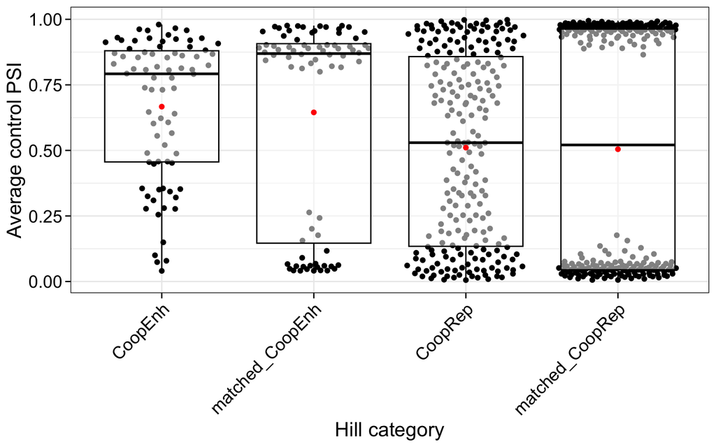

```r
# Extract the control PSIs
CoopEnhPSIs <- regulatedCEs %>%
    dplyr::filter(hillCat == "Coop-Enh") %>%
    pull(Contr_PSI)
CoopRepPSIs <- regulatedCEs %>%
    dplyr::filter(hillCat == "Coop-Rep") %>%
    pull(Contr_PSI)

# The arrange() is necessary as I improved the code and results would otherwise
#   be not identical to the ones in the publication
nonRegulatedCEs <- nonRegulatedCEs %>% arrange(event_id)

# define the quantiles
qCoopEnh <- quantile(CoopEnhPSIs, c(0, 0.05, 0.7, 0.8, 1))
qCoopRep <- quantile(CoopRepPSIs, c(0, 0.1, 0.65, 0.9, 1))

nonRegulatedCEs$intCoopEnh = findInterval(nonRegulatedCEs$Contr_PSI, qCoopEnh)
nonRegulatedCEs$intCoopRep = findInterval(nonRegulatedCEs$Contr_PSI, qCoopRep)

set.seed(123)

matchedNonRegulatedCEs_Rep <- nonRegulatedCEs %>%
    dplyr::filter(intCoopRep %in% 1:(length(qCoopRep) -1)) %>%
    split(., .$intCoopRep) %>%
    lapply(function(df){
        rows <- sample(1:nrow(df),
                       size=floor(length(CoopRepPSIs)/(length(qCoopRep)-1)),
                       replace=FALSE)
        return(df[rows,])
    }) %>% bind_rows

matchedNonRegulatedCEs_Enh <- nonRegulatedCEs %>%
    dplyr::filter(intCoopEnh %in% 1:(length(qCoopEnh) -1)) %>%
    split(., .$intCoopEnh) %>%
    lapply(function(df){
        rows <- sample(1:nrow(df),
                       size=floor(length(CoopEnhPSIs)/(length(qCoopEnh)-1)),
                       replace=FALSE)
        return(df[rows,])
    }) %>% bind_rows

data.frame(
    hillCat = factor(c(rep("CoopEnh", length(CoopEnhPSIs)),
                       rep("matched_CoopEnh", nrow(matchedNonRegulatedCEs_Enh)),
                       rep("CoopRep", length(CoopRepPSIs)),
                       rep("matched_CoopRep", nrow(matchedNonRegulatedCEs_Rep))),
                     levels = c("CoopEnh", "matched_CoopEnh",
                                "CoopRep", "matched_CoopRep")),
    Contr_PSI = c(CoopEnhPSIs, matchedNonRegulatedCEs_Enh$Contr_PSI,
                  CoopRepPSIs, matchedNonRegulatedCEs_Rep$Contr_PSI)
) %>%
    ggplot(., aes(x=hillCat, y=Contr_PSI)) +
        geom_quasirandom() +
        geom_boxplot(alpha=.5, outlier.size = -1, col="black") +
        stat_summary(fun.y="mean", geom="point", col="red")+
        labs(x="Hill category", y="Average control PSI") +
        myTheme +
        theme(axis.text.x = element_text(angle=45, vjust=1, hjust=1))
```

The matched distributions are not perfect but median and mean (red point) are especially for the repressed CE events very similar.

## 4.2 Measuring iCLIP signal around splice sites

For the RNAmaps the iCLIP signal around the upstream 5’ splice site, the upstream 3’ splice, the downstream 5’ splice site and the downstream 3’ splice sites is used.

Around each of the four splice sites a window is opened, which ranges up to 50 nts into exons and up to 300 nts into introns. If exons or introns are shorter than 50 nts and 300 nts, respectively, the missing nucleotides are internally replaced by NAs.

The procedure above was done for each individual CE event. Signals in the four windows were ultimately combined by the Hill category into matrices, where rows are individual CE events and columns the 351 nt wide windows around the splice sites.

```r
# This function creates for each Hill category and each splice site
#   the matrices.
#   The upstream 5' splice site is the 3' end of the C1 exon
#   The upstream 3' splice site is the 5' end of the A exon
#   The downstream 5' splice site is the 3' end of the A exon
#   The downstream 3' splice site is the 5' end of the C2 exon
createMatrix <- function(miniGenes, exon, exonEnd){
    # Iterate over each minigene provided
    lapply(miniGenes, function(gr){

        # Define the first and second exon
        if(exon=="C1"){
            exon2 <- "A"
        } else if(exon=="A" & exonEnd=="5prime"){
            exon2 <- "C1"
        } else if(exon=="A" & exonEnd=="3prime"){
            exon2 <- "C2"
        } else {
            exon2 <- "A"
        }

        # Subset the GRanges object to the two determined exons
        gr <- gr[gr$exon %in% c(exon, exon2)]

        # Get the width of the involved intron
        intronWidth <- width(gaps(gr, start=NA, end=NA))

        # Subset the GRanges object further to the exon the splice site is
        #   located on
        gr <- gr[gr$exon==exon]

        # Get the width of the involved exon
        exonWidth <- width(gr)

        # Reduce the GRanges object to a single nt (this is the splice site)
        gr <- resize(gr[gr$exon==exon], 1,
                     fix= ifelse(exonEnd == "5prime", "start" , "end"))

        # Using promoters() the up to 351 nt range is created.
        if(exonEnd == "5prime"){
            upstream <- min(c(300, intronWidth))
            downstream <- min(c(50, exonWidth))
            gr <- promoters(gr, upstream = upstream, downstream=downstream+1)
        } else {
            upstream <- min(c(50, exonWidth))
            downstream <- min(c(300, intronWidth))
            gr <- promoters(gr, upstream = upstream, downstream=downstream+1)
        }

        # Get the strand
        strand <- strand(gr) %>% as.character

        # The iCLIP signal in the window is extracted by subsetting the RleList
        if(strand == "+"){
            signalInWindow <-  crosslinkSites$`+`[gr][[1]] %>% as.numeric
        } else {
            signalInWindow <- crosslinkSites$`-`[gr][[1]] %>% as.numeric %>% rev
            }

        # If the exon is short than 50 nt or the intron shorter than 300 nt
        #   NAs need to be added to the numeric vector.
        if(exon=="C1"){
            leftNAs <- ifelse(exonWidth < 50, 50-exonWidth, 0)
            rightNAs <- ifelse(intronWidth < 300, 300-intronWidth, 0)
        } else if(exon=="A" & exonEnd=="5prime"){
            leftNAs <- ifelse(intronWidth < 300, 300-intronWidth, 0)
            rightNAs <- ifelse(exonWidth < 50, 50-exonWidth, 0)
        } else if(exon=="A" & exonEnd=="3prime"){
            leftNAs <- ifelse(exonWidth < 50, 50-exonWidth, 0)
            rightNAs <- ifelse(intronWidth < 300, 300-intronWidth, 0)
        } else {
            leftNAs <- ifelse(intronWidth < 300, 300-intronWidth, 0)
            rightNAs <- ifelse(exonWidth < 50, 50-exonWidth, 0)
        }
        signalInWindow <- c(rep(NA, leftNAs), signalInWindow, rep(NA, rightNAs))

        return(signalInWindow)

        }) %>% as.data.frame %>% as.matrix %>% t
}



# Prepare the four matrices for the regulated CE events
C1_3prime_mat <- createMatrix(regulatedMiniGenes,
                              exon="C1",
                              exonEnd="3prime")
A_5prime_mat <- createMatrix(regulatedMiniGenes,
                             exon="A",
                             exonEnd="5prime")
A_3prime_mat <- createMatrix(regulatedMiniGenes,
                             exon="A",
                             exonEnd="3prime")
C2_5prime_mat <- createMatrix(regulatedMiniGenes,
                              exon="C2",
                              exonEnd="5prime")

# The Hill category is added as rowname. This allows the splitting into
#   cooperatively enhanced and repressed exons
rownames(C1_3prime_mat) <- regulatedMiniGenes %>%
    sapply(., function(gr){gr$hillCat %>% unique})
rownames(A_5prime_mat) <- regulatedMiniGenes %>%
    sapply(., function(gr){gr$hillCat %>% unique})
rownames(A_3prime_mat) <- regulatedMiniGenes %>%
    sapply(., function(gr){gr$hillCat %>% unique})
rownames(C2_5prime_mat) <- regulatedMiniGenes %>%
    sapply(., function(gr){gr$hillCat %>% unique})

# Prepare the four matrices for the non-regulated CE events

# Subset the non-regulated minigenes to those matched by PSI
matchedNonRegulatedMiniGenes_Enh <- nonRegulatedMiniGenes[
    names(nonRegulatedMiniGenes) %in% matchedNonRegulatedCEs_Enh$event_id]
matchedNonRegulatedMiniGenes_Rep <- nonRegulatedMiniGenes[
    names(nonRegulatedMiniGenes) %in% matchedNonRegulatedCEs_Rep$event_id]

matchedCoopRepC1_3prime_mat <- createMatrix(matchedNonRegulatedMiniGenes_Rep,
                                            exon="C1",
                                            exonEnd="3prime")
matchedCoopRepA_5prime_mat <- createMatrix(matchedNonRegulatedMiniGenes_Rep,
                                           exon="A",
                                           exonEnd="5prime")
matchedCoopRepA_3prime_mat <- createMatrix(matchedNonRegulatedMiniGenes_Rep,
                                           exon="A",
                                           exonEnd="3prime")
matchedCoopRepC2_5prime_mat <- createMatrix(matchedNonRegulatedMiniGenes_Rep,
                                            exon="C2",
                                            exonEnd="5prime")

matchedCoopEnhC1_3prime_mat <- createMatrix(matchedNonRegulatedMiniGenes_Enh,
                                            exon="C1",
                                            exonEnd="3prime")
matchedCoopEnhA_5prime_mat <- createMatrix(matchedNonRegulatedMiniGenes_Enh,
                                           exon="A",
                                           exonEnd="5prime")
matchedCoopEnhA_3prime_mat <- createMatrix(matchedNonRegulatedMiniGenes_Enh,
                                           exon="A",
                                           exonEnd="3prime")
matchedCoopEnhC2_5prime_mat <- createMatrix(matchedNonRegulatedMiniGenes_Enh,
                                            exon="C2",
                                            exonEnd="5prime")
```

As a small number of windows with very strong signals might dominate the RNAmaps, a row-wise min-max normalization ((x-min) / (max-min)) was performed.

```r
# Signals are min-max nomalized by row. NaNs are replaced by 0 afterwards
minMaxNorm <- function(mat){
    mat <- apply(mat, 1, function(row){
        (row-min(row, na.rm=TRUE))/ (max(row, na.rm=TRUE)-min(row, na.rm=TRUE))
        }) %>% t
    mat[is.nan(mat)] <- 0
    return(mat)
}

# Regulated
C1_3prime_mat <- minMaxNorm(C1_3prime_mat)
A_5prime_mat <- minMaxNorm(A_5prime_mat)
A_3prime_mat <- minMaxNorm(A_3prime_mat)
C2_5prime_mat <- minMaxNorm(C2_5prime_mat)

# Non-regulated
matchedCoopEnhC1_3prime_mat <- minMaxNorm(matchedCoopEnhC1_3prime_mat)
matchedCoopEnhA_5prime_mat <- minMaxNorm(matchedCoopEnhA_5prime_mat)
matchedCoopEnhA_3prime_mat <- minMaxNorm(matchedCoopEnhA_3prime_mat)
matchedCoopEnhC2_5prime_mat <- minMaxNorm(matchedCoopEnhC2_5prime_mat)

matchedCoopRepC1_3prime_mat <- minMaxNorm(matchedCoopRepC1_3prime_mat)
matchedCoopRepA_5prime_mat <- minMaxNorm(matchedCoopRepA_5prime_mat)
matchedCoopRepA_3prime_mat <- minMaxNorm(matchedCoopRepA_3prime_mat)
matchedCoopRepC2_5prime_mat <- minMaxNorm(matchedCoopRepC2_5prime_mat)
```

## 4.3 RNAmap creation

RNAmaps are created for enhanced and reprssed CE events separately. In each RNAmap also the signal of the matched non-regulated CE Events is shown. The signal is the averaged min-max normalized iCLIP signal of the CE events at a specific nucleotide. Signal is also shown with loess-smoothing to get clearer signals.

In each of the two RNAmaps the signals of enhanced and repressed CE events can be compared against the signal of the matched non-regulated CE events. To easily identify regions with strong signal differences, 10 nt bins with a step size of 1 are created. For each of the 342 (351-10+1) bins the signal on the 10 nts is averaged for each CE event, and the average signals per bin compared between the enhanced / repressed groups and their matched non-regulated counterparts using wilcox.test, followed by FDR correction across all 342 tested bins.

In the first step, the data.frames with the raw signals around each of the four splice sites are prepared for the enhanced and repressed CE events and their matched non-regulated CE events.

```r
# This function creates the data.frames with the raw signals
createRNAmapDf  <- function(hillCat){

    positionColumn <- rep(1:351, 4)
    spliceSiteColumn <- factor(c(rep("C1_3prime", 351),
                                 rep("A_5prime", 351),
                                 rep("A_3prime", 351),
                                 rep("C2_5prime", 351)),
                               levels=c("C1_3prime", "A_5prime",
                                        "A_3prime", "C2_5prime"))

    # Create the data.frame with the raw signal for the Cooperative set
    signalColumn <- c(
        colMeans(C1_3prime_mat[rownames(C1_3prime_mat) == hillCat,], na.rm=TRUE),
        colMeans(A_5prime_mat[rownames(A_5prime_mat) == hillCat,], na.rm=TRUE),
        colMeans(A_3prime_mat[rownames(A_3prime_mat) == hillCat,], na.rm=TRUE),
        colMeans(C2_5prime_mat[rownames(C2_5prime_mat) == hillCat,], na.rm=TRUE))


    RNAmapDf_Coop <- data.frame(pos = positionColumn,
                                spliceSite= spliceSiteColumn,
                                signal= signalColumn,
                                set=hillCat)

    # Create the data.frame with the raw signal for the matched set
    if(hillCat == "Coop-Enh"){
        signalColumn <- c(
            colMeans(matchedCoopEnhC1_3prime_mat, na.rm=TRUE),
            colMeans(matchedCoopEnhA_5prime_mat, na.rm=TRUE),
            colMeans(matchedCoopEnhA_3prime_mat, na.rm=TRUE),
            colMeans(matchedCoopEnhC2_5prime_mat, na.rm=TRUE))
    } else {
        signalColumn <- c(
            colMeans(matchedCoopRepC1_3prime_mat, na.rm=TRUE),
            colMeans(matchedCoopRepA_5prime_mat, na.rm=TRUE),
            colMeans(matchedCoopRepA_3prime_mat, na.rm=TRUE),
            colMeans(matchedCoopRepC2_5prime_mat, na.rm=TRUE))
    }

    RNAmapDf_matched <- data.frame(pos = positionColumn,
                                spliceSite= spliceSiteColumn,
                                signal= signalColumn,
                                set="matched")

    return(list(RNAmapDf_Coop, RNAmapDf_matched))
}


tmp <- createRNAmapDf(hillCat = "Coop-Enh")
RNAmapDf_Enh <- tmp[[1]]
RNAmapDf_Enh_matched <- tmp[[2]]

tmp <- createRNAmapDf(hillCat = "Coop-Rep")
RNAmapDf_Rep <- tmp[[1]]
RNAmapDf_Rep_matched <- tmp[[2]]
rm(tmp)
```

In the next step, the 342 bins are created and test for signal differences between the regulated CE events and the matched non-regulated CE events.

```r
# This functions identifies bins with significant signal differences
#   in the windows around each of the four splice sites
determineSignificantBins <- function(hillCat){

    binSize <- 10

    # Determine significant bins for each of the four splice sites

    # C1_3prime
    # Raw iCLIP signal is extracted for the cooperatively regulated CE events
    #   and the matched non-regulated events
    coop <- C1_3prime_mat[rownames(C1_3prime_mat) == hillCat,]
    if(hillCat == "Coop-Enh"){
        matched <- matchedCoopEnhC1_3prime_mat
    } else {
        matched <- matchedCoopRepC1_3prime_mat
    }

    # 10 nt bins are defined and the average signal determined for each
    #   CE event. Averages are compared between cooperatively regulated
    #   and the matched non-regulated CEe events using wilcox.test, followed
    #   by FDR correction
    FDR <- sapply(1:(351-binSize+1), function(i){
        wilcox.test(coop[,i:(i+binSize-1)] %>% rowMeans(., na.rm = T),
                    matched[,i:(i+binSize-1)] %>% rowMeans(., na.rm = T),
                    alternative="greater")$p.value}) %>%
        p.adjust(., method = "BH")

    # Final data.frame contains all significant bins (FDR <= 0.01)
    C1_3prime_significantBins <- data.frame(
        binStart = 1:(351-binSize+1),
        binEnd = 1:(351-binSize+1)+(binSize-1),
        FDR = FDR
    ) %>% dplyr::filter(FDR <= 0.01)


    # A_5prime
    # Raw iCLIP signal is extracted for the cooperatively regulated CE events
    #   and the matched non-regulated events
    coop <- A_5prime_mat[rownames(A_5prime_mat) == hillCat,]
    if(hillCat == "Coop-Enh"){
        matched <- matchedCoopEnhA_5prime_mat
    } else {
        matched <- matchedCoopRepA_5prime_mat
    }

    # 10 nt bins are defined and the average signal determined for each
    #   CE event. Averages are compared between cooperatively regulated
    #   and the matched non-regulated CEe events using wilcox.test, followed
    #   by FDR correction
    FDR <- sapply(1:(351-binSize+1), function(i){
        wilcox.test(coop[,i:(i+binSize-1)] %>% rowMeans(., na.rm = T),
                    matched[,i:(i+binSize-1)] %>% rowMeans(., na.rm = T),
                    alternative="greater")$p.value}) %>%
        p.adjust(., method = "BH")

    # Final data.frame contains all significant bins (FDR <= 0.01)
    A_5prime_significantBins <- data.frame(
        binStart = 1:(351-binSize+1),
        binEnd = 1:(351-binSize+1)+(binSize-1),
        FDR = FDR
    ) %>% dplyr::filter(FDR <= 0.01)


    # A_3prime
    # Raw iCLIP signal is extracted for the cooperatively regulated CE events
    #   and the matched non-regulated events
    coop <- A_3prime_mat[rownames(A_3prime_mat) == hillCat,]
    if(hillCat == "Coop-Enh"){
        matched <- matchedCoopEnhA_3prime_mat
    } else {
        matched <- matchedCoopRepA_3prime_mat
    }

    # 10 nt bins are defined and the average signal determined for each
    #   CE event. Averages are compared between cooperatively regulated
    #   and the matched non-regulated CEe events using wilcox.test, followed
    #   by FDR correction
    FDR <- sapply(1:(351-binSize+1), function(i){
        wilcox.test(coop[,i:(i+binSize-1)] %>% rowMeans(., na.rm = T),
                    matched[,i:(i+binSize-1)] %>% rowMeans(., na.rm = T),
                    alternative="greater")$p.value}) %>%
        p.adjust(., method = "BH")

    # Final data.frame contains all significant bins (FDR <= 0.01)
    A_3prime_significantBins <- data.frame(
        binStart = 1:(351-binSize+1),
        binEnd = 1:(351-binSize+1)+(binSize-1),
        FDR = FDR
    ) %>% dplyr::filter(FDR <= 0.01)


    # C2_5prime
    # Raw iCLIP signal is extracted for the cooperatively regulated CE events
    #   and the matched non-regulated events
    coop <- C2_5prime_mat[rownames(C2_5prime_mat) == hillCat,]
    if(hillCat == "Coop-Enh"){
        matched <- matchedCoopEnhC2_5prime_mat
    } else {
        matched <- matchedCoopEnhC2_5prime_mat
    }

    # 10 nt bins are defined and the average signal determined for each
    #   CE event. Averages are compared between cooperatively regulated
    #   and the matched non-regulated CEe events using wilcox.test, followed
    #   by FDR correction
    FDR <- sapply(1:(351-binSize+1), function(i){
        wilcox.test(coop[,i:(i+binSize-1)] %>% rowMeans(., na.rm = T),
                    matched[,i:(i+binSize-1)] %>% rowMeans(., na.rm = T),
                    alternative="greater")$p.value}) %>%
        p.adjust(., method = "BH")

    # Final data.frame contains all significant bins (FDR <= 0.01)
    C2_5prime_significantBins <- data.frame(
        binStart = 1:(351-binSize+1),
        binEnd = 1:(351-binSize+1)+(binSize-1),
        FDR = FDR
    ) %>% dplyr::filter(FDR <= 0.01)

    return(list(C1_3prime_significantBins, A_5prime_significantBins,
                A_3prime_significantBins, C2_5prime_significantBins))
}

tmp <- determineSignificantBins(hillCat = "Coop-Enh")
C1_3prime_significantBins_Enh <- tmp[[1]]
A_5prime_significantBins_Enh <- tmp[[2]]
A_3prime_significantBins_Enh <- tmp[[3]]
C2_5prime_significantBins_Enh <- tmp[[4]]

tmp <- determineSignificantBins(hillCat = "Coop-Rep")
C1_3prime_significantBins_Rep <- tmp[[1]]
A_5prime_significantBins_Rep <- tmp[[2]]
A_3prime_significantBins_Rep <- tmp[[3]]
C2_5prime_significantBins_Rep <- tmp[[4]]
rm(tmp)
```

After calculing the raw signal and significant bins, the RNAmaps can be generated.

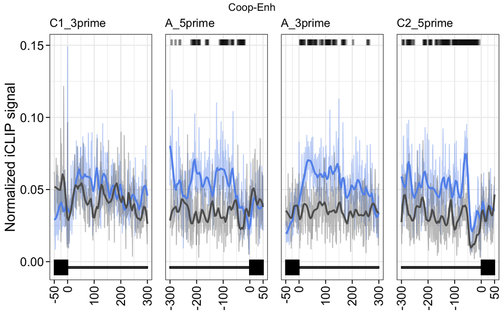

```r
createRNAmap <- function(hillCat){

    # Correct data.frames are determined
    if(hillCat == "Coop-Enh"){
        RNAmapDf <- rbind(RNAmapDf_Enh, RNAmapDf_Enh_matched     )

        C1_3prime_significantBins <- C1_3prime_significantBins_Enh
        A_5prime_significantBins <- A_5prime_significantBins_Enh
        A_3prime_significantBins <- A_3prime_significantBins_Enh
        C2_5prime_significantBins <- C2_5prime_significantBins_Enh
    } else {
        RNAmapDf <- rbind(RNAmapDf_Rep, RNAmapDf_Rep_matched)

        C1_3prime_significantBins <- C1_3prime_significantBins_Rep
        A_5prime_significantBins <- A_5prime_significantBins_Rep
        A_3prime_significantBins <- A_3prime_significantBins_Rep
        C2_5prime_significantBins <- C2_5prime_significantBins_Rep
    }

    # For each splice site a single plot is generated. The plots contain
    #   raw signals, loess-smoothed signals, the underlying exons and
    #   intron and, if present, significant bins at the top of the plot

    p1 <- ggplot(RNAmapDf %>% dplyr::filter(spliceSite == "C1_3prime"),
                 aes(x=pos, y=signal, col=set)) +
            geom_line(alpha=0.4, size=.5) +
            geom_smooth(se=FALSE, method = "loess", span = 0.1, size=1) +
            geom_rect(mapping=aes(xmin=1, xmax=51, ymin=-0.009, ymax=0.001),
                      fill="black", col="black") +
            geom_rect(mapping=aes(xmin=52, xmax=351, ymin=-0.00445,
                                  ymax=-0.00355), fill="darkgrey", col="black") +
            scale_color_manual(values=c("Coop-Enh"="cornflowerblue",
                                        "Coop-Rep"="salmon2",
                                        "matched"="#606060")) +
            scale_x_continuous(breaks=c(1,51,151, 251, 351),
                               labels = c(-50, 0, 100, 200, 300)) +
            scale_y_continuous(breaks=seq(0, 0.15, 0.05)) +
            coord_cartesian(ylim=c(-0.005,0.15)) +
            labs(x="Position relative to splice site",
                 y="Normalized iCLIP signal", title="C1_3prime") +
            myTheme +
            theme(axis.text.x = element_text(angle=90, vjust=0.5, hjust=1))

    # If there are significant bins label them in the plot. Alpha is 0.25
    #   leading to black if a position is part of at least 4 significant
    #   bins
    if(nrow(C1_3prime_significantBins) != 0){
        p1 <- p1 + geom_rect(data=C1_3prime_significantBins,
                             mapping=aes(xmin=binStart, xmax=binEnd,
                                         ymin=0.15, ymax=0.154),
                             fill="black", inherit.aes = FALSE,alpha=.25)
        }

    p2 <- ggplot(RNAmapDf %>% dplyr::filter(spliceSite == "A_5prime"),
                 aes(x=pos, y=signal, col=set)) +
            geom_line(alpha=0.4, size=.5) +
            geom_smooth(se=FALSE, method = "loess", span = 0.1, size=1) +
            geom_rect(mapping=aes(xmin=301, xmax=351, ymin=-0.009, ymax=0.001),
                      fill="black", col="black") +
            geom_rect(mapping=aes(xmin=1, xmax=300,
                                  ymin=-0.00445, ymax=-0.00355),
                      fill="darkgrey", col="black") +
            scale_color_manual(values=c("Coop-Enh"="cornflowerblue",
                                        "Coop-Rep"="salmon2",
                                        "matched"="#606060")) +
            scale_x_continuous(breaks=c(1, 101, 201, 301, 351),
                               labels = c(-300, -200, -100, 0, 50)) +
            scale_y_continuous(breaks=seq(0, 0.15, 0.05)) +
            coord_cartesian(ylim=c(-0.005,0.15)) +
            labs(x="Position relative to splice site",
                 y="Normalized iCLIP signal", title="A_5prime") +
            myTheme +
            theme(axis.text.x = element_text(angle=90, vjust=0.5, hjust=1))

    # If there are significant bins label them in the plot. Alpha is 0.25
    #   leading to black if a position is part of at least 4 significant
    #   bins
    if(nrow(A_5prime_significantBins) != 0){
        p2 <- p2 + geom_rect(data=A_5prime_significantBins,
                             mapping=aes(xmin=binStart, xmax=binEnd,
                                         ymin=0.15, ymax=0.154),
                             fill="black", inherit.aes = FALSE,alpha=.25)
        }

    p3 <- ggplot(RNAmapDf %>% dplyr::filter(spliceSite == "A_3prime"),
                 aes(x=pos, y=signal, col=set)) +
            geom_line(alpha=0.4, size=.5) +
            geom_smooth(se=FALSE, method = "loess", span = 0.1, size=1) +
            geom_rect(mapping=aes(xmin=1, xmax=51, ymin=-0.009, ymax=0.001),
                      fill="black", col="black") +
            geom_rect(mapping=aes(xmin=52, xmax=351,
                                  ymin=-0.00445, ymax=-0.00355),
                      fill="darkgrey", col="black") +
            scale_color_manual(values=c("Coop-Enh"="cornflowerblue",
                                        "Coop-Rep"="salmon2",
                                        "matched"="#606060")) +
            scale_x_continuous(breaks=c(1,51,151, 251, 351),
                               labels = c(-50, 0, 100, 200, 300)) +
            scale_y_continuous(breaks=seq(0, 0.15, 0.05)) +
            coord_cartesian(ylim=c(-0.005,0.15)) +
            labs(x="Position relative to splice site",
                 y="Normalized iCLIP signal", title="A_3prime") +
            myTheme +
            theme(axis.text.x = element_text(angle=90, vjust=0.5, hjust=1))

    # If there are significant bins label them in the plot. Alpha is 0.25
    #   leading to black if a position is part of at least 4 significant
    #   bins
    if(nrow(A_3prime_significantBins) != 0){
        p3 <- p3 + geom_rect(data=A_3prime_significantBins,
                             mapping=aes(xmin=binStart, xmax=binEnd,
                                         ymin=0.15, ymax=0.154),
                             fill="black", inherit.aes = FALSE,alpha=.25)
        }

    p4 <- ggplot(RNAmapDf %>% dplyr::filter(spliceSite == "C2_5prime"),
                 aes(x=pos, y=signal, col=set)) +
            geom_line(alpha=0.4, size=.5) +
            geom_smooth(se=FALSE, method = "loess", span = 0.1, size=1) +
            geom_rect(mapping=aes(xmin=301, xmax=351, ymin=-0.009, ymax=0.001), fill="black", col="black") +
            geom_rect(mapping=aes(xmin=1, xmax=300, ymin=-0.00445, ymax=-0.00355), fill="darkgrey", col="black") +
            scale_color_manual(values=c("Coop-Enh"="cornflowerblue",
                                        "Coop-Rep"="salmon2",
                                        "matched"="#606060")) +
            scale_x_continuous(breaks=c(1, 101, 201, 301, 351),
                               labels = c(-300, -200, -100, 0, 50)) +
            scale_y_continuous(breaks=seq(0, 0.15, 0.05)) +
            coord_cartesian(ylim=c(-0.005,0.15)) +
            labs(x="Position relative to splice site",
                 y="Normalized iCLIP signal", title="C2_5prime") +
            myTheme +
            theme(axis.text.x = element_text(angle=90, vjust=0.5, hjust=1))

    # If there are significant bins label them in the plot. Alpha is 0.25
    #   leading to black if a position is part of at least 4 significant
    #   bins
    if(nrow(C2_5prime_significantBins) != 0){
        p4 <- p4 + geom_rect(data=C2_5prime_significantBins,
                             mapping=aes(xmin=binStart, xmax=binEnd,
                                         ymin=0.15, ymax=0.154),
                             fill="black", inherit.aes = FALSE,alpha=.25)
        }

    egg::ggarrange(p1 + theme(axis.title.x = element_blank()),
                  p2 + theme(axis.title.x = element_blank(),
                             axis.title.y = element_blank(),
                             axis.text.y = element_blank(),
                             axis.ticks.y = element_blank()),
                  p3 + theme(axis.title.x = element_blank(),
                             axis.title.y = element_blank(),
                             axis.text.y = element_blank(),
                             axis.ticks.y = element_blank()),
                  p4 + theme(axis.title.x = element_blank(),
                             axis.title.y = element_blank(),
                             axis.text.y = element_blank(),
                             axis.ticks.y = element_blank()),
                  nrow = 1, top = hillCat)
}

createRNAmap(hillCat = "Coop-Enh")
```

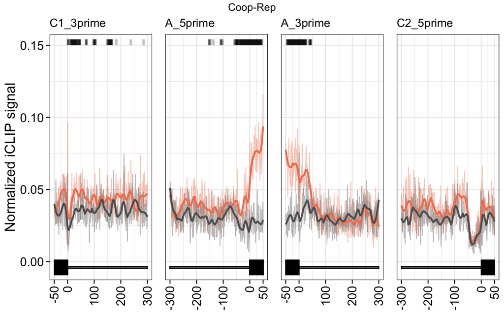

```r
createRNAmap(hillCat = "Coop-Rep")
```

It becomes clear that HNRNPH binding is enriched in introns of enhanced CE events and on the alternative exon of repressed CE events.